# Treatment Effect of Tranexamic Acid on stratified TBI patients

Imke Mayer

In this R markdown we analyze the Traumabase Registry to estimate the treatment effect of the drug Tranexamic Acid (TXA) on mortality among patients with traumatic brain injury (TBI), stratified along 2 different criteria of severity.

For this analysis, an expert committee has identified 17 confounders available in the Traumabase: `Trauma.center`, `Cardiac.arrest.ph`, `SBP.ph.min, DBP.ph.min, HR.ph.max`, `SBP.ph, DBP.ph, HR.ph`, `Shock.index.ph` (`HR.ph`/`SBP.ph`), `Cristalloid.volume`, `Colloid.volume`, `SpO2.ph.min`, `Vasopressor.therapy`, `HemoCue.init`, `Delta.hemoCue`, `AIS.external`, `Activation.HS.procedure`.

# 1 Preliminaries

## 1.1 Load libraries

```r
library(cobalt)
library(ggplot2)
library(dplyr)
library(reshape2)
library(tableone)
library(MASS)
library(pracma)
library(assertthat)

library(caret) #
library(ranger)# Random Forests prediction
library(FactoMineR) # Factorial data analysis
library(grf) # Doubly robust treatment effect estimation

library(norm)
library(missMDA) # PCA/MCA with missing values + iterative PC imputation
library(mice) # Multiple imputation
library(VIM) # Missing values exploration and visualization

# Define data directory
data.dir <- "~/Documents/TraumaMatrix/CausalInference/AcideTranexamique/Data/"
rdata.dir <- "~/Documents/TraumaMatrix/CausalInference/Simulations/causal-inference-missing/TranexamicAcid/RData/"
fig.dir <- "~/Documents/TraumaMatrix/CausalInference/Simulations/causal-inference-missing/TranexamicAcid/Figures/"

library(devtools)
# Load the ATE estimation functions `ipw` and `dr` from the GitHub repository
source_url("https://raw.githubusercontent.com/imkemayer/causal-inference-missing/master/Helper/helper_causalInference.R")
```

```
## SHA-1 hash of file is 72aa0bae8732bb83bbb18ae5189baae2b7171c71
```

```r
source_url("https://raw.githubusercontent.com/imkemayer/causal-inference-missing/master/Helper/helper_imputation.R")
```

```
## SHA-1 hash of file is 66fca1a6480553b69007d1f9896cd3097606fb98
```

```r
save_results <- FALSE
tau <- NULL
# Set random generator seed for reproducible results
set.seed(0)
```

## 1.2 Load data

Run R markdown `preprocess_ate_analysis_traumabase_example.Rmd` prior to this to pre-process and save the data for the following analyses.

```r
data_indTBI <- read.csv(paste0(data.dir,
                               "ate_analysis_traumabase_large_data_preprocessed_tbi_individuals.csv"),
                        row.names = 1)
seed <- 1234
```

```r
synthetic <- FALSE

X.na <- data_indTBI[,setdiff(colnames(data_indTBI),
                          c("TBI", "Tranexamic.acid", "Death"))]

W <- data_indTBI$Tranexamic.acid
Y <- data_indTBI$Death

covariate_names <- colnames(X.na)
n <- dim(X.na)[1]
p <- dim(X.na)[2]

df.na <- data.frame(cbind(X.na, W=W, Y=Y))
colnames(df.na) <- c(covariate_names, "W", "Y")
```

This pipeline requires `W` to be binary and coded either with `{0,1}` or with `{FALSE,TRUE}`, representing `{control,treatment}`.

```r
assert_that(length(unique(W))==2)
```

```
## [1] TRUE
```

```r
assert_that(unique(W) %in% c(0,1) || unique(W) %in% c(FALSE,TRUE))
```

```
## [1] TRUE
```

In certain cases, not all covariates are necessarily confounders. Therefore we specify the set of confounders in `confounder_names`. Additionally, in some cases there are also variables that are only predictive of the treatment assignment. Their names can be specified in `only_treatment_pred_names`.

```r
confounder_names <- c("Trauma.center",
                      "SBP.ph", "DBP.ph", "HR.ph",
                      "SBP.ph.min", "DBP.ph.min", "HR.ph.max",
                      "Cardiac.arrest.ph", "Vasopressor.therapy", "SpO2.ph.min",
                      "AIS.external", "HemoCue.init", "Delta.hemoCue",
                      "Shock.index.ph", "Cristalloid.volume", "Colloid.volume",
                      "Activation.HS.procedure")
only_treatment_pred_names <- c()
only_outcome_pred_names <- setdiff(covariate_names,
                                   c(confounder_names, only_treatment_pred_names))
```

For the DR estimation, we can specify clusters, here we will use the Trauma centers as clusters.

```r
cluster_names <- c("Trauma.center")
```

We list binary and other categorical variables to ensure correct type casts.

```r
binary_names <- intersect(covariate_names,
                          c("Cardiac.arrest.ph", "Anticoagulant.therapy",
                            "Antiplatelet.therapy", "EVD", "Activation.HS.procedure",
                            "Neurosurgery.day0", "Fi02", "Vasopressor.therapy"))

categorical_names <- intersect(covariate_names,
                               c("Trauma.center", "Pupil.anomaly",
                                 "Osmotherapy", "Osmotherapy.ph",
                                 "Pupil.anomaly.ph",
                                 "Improv.anomaly.osmo"))
```

It is possible that during the loading of the data set, certain variables are not cast correctly. We check that the variable types are all correct according to the specified types in `binary_names` and `categorical_names`.

Look at the `Activation.HS.procedure` variable. The treatment TXA is generally given to prevent the occurrence of hemorrhagic shock, a condition which is often fatal. Let us see how is the treatment distributed w.r.t. this variable.

```r
res.table <- table(df.na$W==1, df.na$Activation.HS.procedure,
                   dnn = c("Treated","Activation.HS.procedure"),
                   useNA = "ifany")
print(res.table)
```

```
##        Activation.HS.procedure
## Treated FALSE TRUE <NA>
##   FALSE  6939  345  281
##   TRUE    263  392   28
```

## 1.3 List of strata to consider

```r
strata <- list(list("mild_moderate", "df.na[,'GCS.init'] >=9"),
               list("severe", "df.na[,'GCS.init'] <9"),
               list("both_react", "!(df.na[,'Pupil.anomaly.ph'] %in% c('Anisocorie (unilatérale)','Mydriase Bilatérale'))"),
               list("any_non_react", "df.na[,'Pupil.anomaly.ph'] %in% c('Anisocorie (unilatérale)','Mydriase Bilatérale')"))
```

First we compute the unadjusted ATE, ignoring the confounders.

```r
ate_raw <- c()
for (stratum in strata){
  df_stratum <- df.na[which(eval(parse(text=stratum[[2]]))),]
  ate_raw <- rbind(ate_raw,
                   cbind(stratum[[1]], mean(df_stratum$Y[which(as.logical(df_stratum$W))]) - mean(df_stratum$Y[which(!as.logical(df_stratum$W))])))
}
colnames(ate_raw) <- c("Stratum", "ate_raw")
ate_raw <- data.frame(ate_raw)
ate_raw$ate_raw <- as.numeric(ate_raw$ate_raw)
ate_raw
```

```
##         Stratum   ate_raw
## 1 mild_moderate 0.1641989
## 2        severe 0.2561275
## 3    both_react 0.2536991
## 4 any_non_react 0.2574062
```

Let us also assess how the outcome is distributed with respect to the treatment group.

```r
for (stratum in strata) {
  df_stratum <- df.na[which(eval(parse(text=stratum[[2]]))),]
  if (length(unique(Y))==2){
    print(stratum[[1]])
    res.table <- table(as.factor(df_stratum$W), as.factor(df_stratum$Y),
                       dnn = c("W","Y"))
    print(prop.table(res.table))
  } else {
    ggplot(data.frame(W=as.factor(df_stratum$W), Y=df_stratum$Y)) +
      geom_histogram(aes(Y, color=W), fill = "white") +
      ggtitle(stratum[[1]])
  }
}
```

```
## [1] "mild_moderate"
##    Y
## W            0          1
##   0 0.88427697 0.05700077
##   1 0.04552410 0.01319816
## [1] "severe"
##    Y
## W            0          1
##   0 0.51663748 0.35446585
##   1 0.04343257 0.08546410
## [1] "both_react"
##    Y
## W            0          1
##   0 0.81021583 0.11568345
##   1 0.04604317 0.02805755
## [1] "any_non_react"
##    Y
## W            0          1
##   0 0.46764253 0.40292758
##   1 0.03620955 0.09322034
```

# 2 Imputation

We impute the data with two different methods (iterative FAMD, mice).

## 2.1 FAMD

*Note that for this approach, an alternative would be to go back to the original dataset, instead of focusing just on the patients with TBI and/or `AIS.head >= 2` to impute the missing data. Even though we will only keep the patients with TBI and/or `AIS.head>=2` while running the causal analysis, including the other patients at this stage can allow the imputation of missing data to be more informed by adding additional observations for comparison purposes.*

Let’s look at the matrix plot to identify if there are any variables that tend to be missing together or if we can detect any clear violation of the missing completely at random hypothesis:

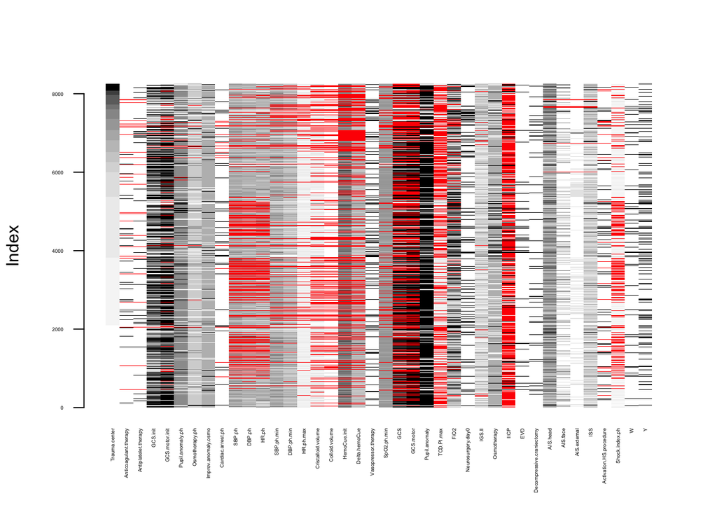

```
##
## Click in a column to sort by the corresponding variable.
## To regain use of the VIM GUI and the R console, click outside the plot region.
```

```r
matrixplot(df.na, sortby = 1, las=2, cex.axis = 0.3)
```

We can also run MCA on the missing and non missing entries to double check our conclusion and to check if other groups of variables tend to be missing together:

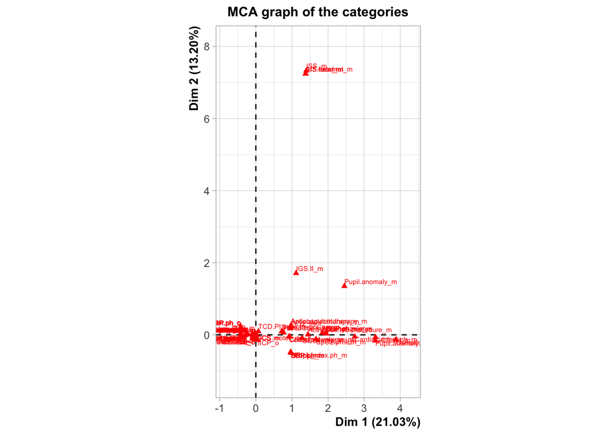

```r
data_miss <- data.frame(is.na(df.na))
data_miss <- apply(X=data_miss, FUN=function(x) if(x) "m" else "o", MARGIN=c(1,2))
res.mca <- MCA(data_miss, graph = FALSE)
plot(res.mca, invis = "ind", title = "MCA graph of the categories", cex =0.5)
```

We now perform a single imputation with a (regularized) iterative Factorial Analysis for Mixed Data model, which will allow imputation to take into account similarities between both individuals and relationships between variables. See: https://arxiv.org/pdf/1301.4797.pdf

First we find the optimal number of dimensions for the FAMD by cross-validation

**Attention: this computation might take a long time. Set `eval=F` in the chunk header if you want to skip this part.**

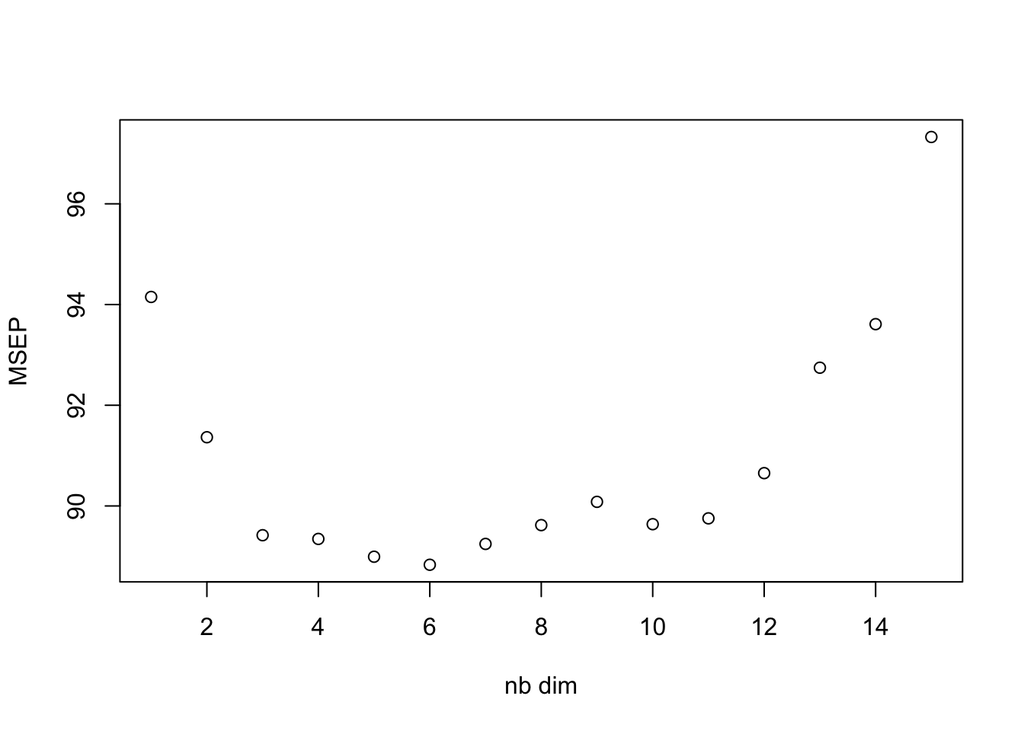

```r
if (file.exists(paste0(rdata.dir, "traumabase_tbi_ncomp_famd.RData"))) {
  load(paste0(rdata.dir, "traumabase_tbi_ncomp_famd.RData"))
  plot(1:length(ncomp_famd$criterion), ncomp_famd$criterion, xlab = "nb dim", ylab = "MSEP")
} else {
  ncomp_famd <- estim_ncpFAMD(df.na,
  ncp.min = 1,
  ncp.max=15,
  method= "Regularized",
  method.cv = "Kfold",
  nbsim=10,
  verbose = TRUE)

  save(ncomp_famd,
       file = paste0(rdata.dir, "traumabase_tbi_ncomp_famd.RData"))
}
```

By cross-validation we find `ncp=6` to be the optimal number of components.

```r
if (file.exists(paste0(rdata.dir, "traumabase_tbi_", length(confounder_names),
                       "confounders_", length(covariate_names),
                       "variables_imputed_famd.RData"))){
  load(file=paste0(rdata.dir, "traumabase_tbi_", length(confounder_names),
                       "confounders_", length(covariate_names),
                       "variables_imputed_famd.RData"))
} else {
  ncp <- 6
  df.imp.pc <- get_FAMD(df.na, seed = 0, ncp=ncp, Method="Regularized",
                        scale=T, threshold = 1e-06)

  save(df.imp.pc, file=paste0(rdata.dir, "traumabase_tbi_",
                              length(confounder_names),
                              "confounders_", length(covariate_names),
                              "variables_imputed_famd.RData"))

}
```

It is possible that during the loading of the imputed data set, certain variables are not cast correctly. We check that the variable types are all correct according to the specified types in `binary_names` and `categorical_names`.

## 2.2 MICE

We also prepare a multiple imputation analysis, using the `mice` package. We impute the data `m=5` times.

```r
if (file.exists(paste0(rdata.dir, "traumabase_tbi_", length(confounder_names),
                       "confounders_", length(covariate_names),
                       "variables_imputed_mice.RData"))) {
  load(file=paste0(rdata.dir, "traumabase_tbi_", length(confounder_names),
                       "confounders_", length(covariate_names),
                       "variables_imputed_mice.RData"))
} else {
  df.imp.mice <- get_MICE(df.na, seed=0, m=5)
  save(df.imp.mice, file=paste0(rdata.dir, "traumabase_tbi_",
                                length(confounder_names), "confounders_",
                                length(covariate_names),
                                "variables_imputed_mice.RData"))
}
```

Again we check and correct the variable types.

# 3 ATE estimation

We are interested in estimating the causal effect of TXA on the mortality of TBI patients, along the different strata.

Although most of the patients receive multiple treatments (in pre-hospital and hospital phase) and we have records of these other treatments (for instance osmotherapy, fibrinogene, etc.) we are only considering the effect of TXA on in-hospital mortality.

## 3.1 IPW

### 3.1.1 On imputed data

```
## Note: Using an external vector in selections is ambiguous.
## ℹ Use `all_of(only_treatment_pred_names)` instead of `only_treatment_pred_names` to silence this message.
## ℹ See <https://tidyselect.r-lib.org/reference/faq-external-vector.html>.
```

```
## Note: Using an external vector in selections is ambiguous.
## ℹ Use `all_of(confounder_names)` instead of `confounder_names` to silence this message.
## ℹ See <https://tidyselect.r-lib.org/reference/faq-external-vector.html>.
```

IPW estimations

| Estimand | Imputation.method | PS.estimation | Mask | Stratum | ATE.normalized | STD.ATE.normalized | ATE.unnormalized |
| --- | --- | --- | --- | --- | --- | --- | --- |
| ATE | pc.imp | glm | FALSE | mild_moderate | 0.41 | 0.29 | 0.51 |
| ATE | pc.imp | glm | FALSE | severe | 0.14 | 0.08 | 0.11 |
| ATE | pc.imp | glm | FALSE | both_react | 0.34 | 0.17 | 0.33 |
| ATE | pc.imp | glm | FALSE | any_non_react | 0.07 | 0.16 | 0.20 |
| ATE | pc.imp | grf.ate | FALSE | mild_moderate | 0.18 | 0.04 | 0.11 |
| ATE | pc.imp | grf.ate | FALSE | severe | 0.14 | 0.05 | 0.04 |
| ATE | pc.imp | grf.ate | FALSE | both_react | 0.18 | 0.04 | 0.10 |
| ATE | pc.imp | grf.ate | FALSE | any_non_react | 0.14 | 0.08 | 0.03 |
| ATE | mice | glm | FALSE | mild_moderate | 0.50 | 0.51 | 0.65 |
| ATE | mice | glm | FALSE | severe | 0.14 | 0.12 | 0.08 |
| ATE | mice | glm | FALSE | both_react | 0.34 | 0.19 | 0.33 |
| ATE | mice | glm | FALSE | any_non_react | 0.05 | 0.40 | 0.15 |
| ATE | mice | grf.ate | FALSE | mild_moderate | 0.17 | 0.05 | 0.10 |
| ATE | mice | grf.ate | FALSE | severe | 0.14 | 0.08 | 0.00 |
| ATE | mice | grf.ate | FALSE | both_react | 0.18 | 0.04 | 0.09 |
| ATE | mice | grf.ate | FALSE | any_non_react | 0.12 | 0.18 | 0.02 |
| ATT | pc.imp | glm | FALSE | mild_moderate | 0.07 | 0.00 | 0.00 |
| ATT | pc.imp | glm | FALSE | severe | 0.06 | 0.01 | 0.00 |
| ATT | pc.imp | glm | FALSE | both_react | 0.13 | 0.01 | -0.01 |
| ATT | pc.imp | glm | FALSE | any_non_react | 0.06 | 0.01 | 0.01 |
| ATT | pc.imp | grf.ate | FALSE | mild_moderate | 0.12 | 0.00 | 0.01 |
| ATT | pc.imp | grf.ate | FALSE | severe | 0.11 | 0.01 | 0.02 |
| ATT | pc.imp | grf.ate | FALSE | both_react | 0.10 | 0.00 | 0.01 |
| ATT | pc.imp | grf.ate | FALSE | any_non_react | 0.12 | 0.01 | 0.02 |
| ATT | mice | glm | FALSE | mild_moderate | 0.10 | 0.01 | 0.00 |
| ATT | mice | glm | FALSE | severe | 0.07 | 0.02 | 0.00 |
| ATT | mice | glm | FALSE | both_react | 0.03 | 0.01 | 0.00 |
| ATT | mice | glm | FALSE | any_non_react | 0.08 | 0.04 | 0.01 |
| ATT | mice | grf.ate | FALSE | mild_moderate | 0.13 | 0.00 | 0.01 |
| ATT | mice | grf.ate | FALSE | severe | 0.10 | 0.01 | 0.02 |

[output cut: 98 more lines]

### 3.1.2 MIA+grf

ipw ATE estimations on mia covariates

| Estimand | Imputation.method | PS.estimation | Mask | Stratum | ATE.normalized | STD.ATE.normalized | ATE.unnormalized |
| --- | --- | --- | --- | --- | --- | --- | --- |
| ATE | mia | grf.ate | TRUE | mild_moderate | 0.17 | 0.04 | 0.09 |
| ATE | mia | grf.ate | TRUE | severe | 0.15 | 0.04 | 0.00 |
| ATE | mia | grf.ate | TRUE | both_react | 0.18 | 0.04 | 0.09 |
| ATE | mia | grf.ate | TRUE | any_non_react | 0.14 | 0.07 | 0.00 |
| ATT | mia | grf.ate | TRUE | mild_moderate | 0.12 | 0.00 | 0.01 |
| ATT | mia | grf.ate | TRUE | severe | 0.10 | 0.01 | 0.02 |
| ATT | mia | grf.ate | TRUE | both_react | 0.09 | 0.00 | 0.01 |
| ATT | mia | grf.ate | TRUE | any_non_react | 0.12 | 0.01 | 0.03 |
| ATC | mia | grf.ate | TRUE | mild_moderate | 0.17 | 0.04 | 0.09 |
| ATC | mia | grf.ate | TRUE | severe | 0.15 | 0.04 | -0.02 |
| ATC | mia | grf.ate | TRUE | both_react | 0.18 | 0.04 | 0.08 |
| ATC | mia | grf.ate | TRUE | any_non_react | 0.14 | 0.06 | -0.02 |
| ATE_overlap | mia | grf.ate | TRUE | mild_moderate | 0.13 | 0.00 | 0.01 |
| ATE_overlap | mia | grf.ate | TRUE | severe | 0.12 | 0.00 | 0.01 |
| ATE_overlap | mia | grf.ate | TRUE | both_react | 0.10 | 0.00 | 0.00 |
| ATE_overlap | mia | grf.ate | TRUE | any_non_react | 0.14 | 0.01 | 0.01 |

## 3.2 DR

### 3.2.1 On imputed data

[output not shown]

[output not shown]

[output not shown]

[output not shown]

DR estimations

| Estimand | Imputation.method | PS.estimation | Mask | Stratum | ATE | STD |
| --- | --- | --- | --- | --- | --- | --- |
| ATE | pc.imp | glm.grf | FALSE | mild_moderate | 0.24 | 0.16 |
| ATE | pc.imp | glm.grf | FALSE | severe | -0.01 | 0.08 |
| ATE | pc.imp | glm.grf | FALSE | both_react | 0.21 | 0.11 |
| ATE | pc.imp | glm.grf | FALSE | any_non_react | -0.16 | 0.16 |
| ATE | pc.imp | grf.ate | FALSE | mild_moderate | 0.07 | 0.05 |
| ATE | pc.imp | grf.ate | FALSE | severe | 0.02 | 0.05 |
| ATE | pc.imp | grf.ate | FALSE | both_react | 0.08 | 0.05 |
| ATE | pc.imp | grf.ate | FALSE | any_non_react | -0.03 | 0.04 |
| ATE | mice | glm.grf | FALSE | mild_moderate | 0.24 | 0.22 |
| ATE | mice | glm.grf | FALSE | severe | 0.00 | 0.10 |
| ATE | mice | glm.grf | FALSE | both_react | 0.15 | 0.11 |
| ATE | mice | glm.grf | FALSE | any_non_react | -0.11 | 0.30 |
| ATE | mice | grf.ate | FALSE | mild_moderate | 0.07 | 0.06 |
| ATE | mice | grf.ate | FALSE | severe | 0.01 | 0.07 |
| ATE | mice | grf.ate | FALSE | both_react | 0.07 | 0.05 |
| ATE | mice | grf.ate | FALSE | any_non_react | -0.02 | 0.10 |
| ATT | pc.imp | glm.grf | FALSE | mild_moderate | 0.03 | 0.03 |
| ATT | pc.imp | glm.grf | FALSE | severe | 0.04 | 0.03 |
| ATT | pc.imp | glm.grf | FALSE | both_react | 0.10 | 0.09 |
| ATT | pc.imp | glm.grf | FALSE | any_non_react | 0.04 | 0.03 |
| ATT | pc.imp | grf.ate | FALSE | mild_moderate | 0.05 | 0.03 |
| ATT | pc.imp | grf.ate | FALSE | severe | 0.04 | 0.03 |
| ATT | pc.imp | grf.ate | FALSE | both_react | 0.04 | 0.04 |
| ATT | pc.imp | grf.ate | FALSE | any_non_react | 0.04 | 0.02 |
| ATT | mice | glm.grf | FALSE | mild_moderate | 0.01 | 0.03 |
| ATT | mice | glm.grf | FALSE | severe | 0.03 | 0.06 |
| ATT | mice | glm.grf | FALSE | both_react | 0.01 | 0.05 |
| ATT | mice | glm.grf | FALSE | any_non_react | 0.03 | 0.21 |
| ATT | mice | grf.ate | FALSE | mild_moderate | 0.05 | 0.03 |
| ATT | mice | grf.ate | FALSE | severe | 0.05 | 0.05 |

[output cut: 98 more lines]

### 3.2.2 MIA+grf

[output not shown]

[output not shown]

[output not shown]

[output not shown]

DR ATE estimations on mia covariates

| Estimand | Imputation.method | PS.estimation | Mask | Stratum | ATE | STD |
| --- | --- | --- | --- | --- | --- | --- |
| ATE | mia | grf.ate | FALSE | mild_moderate | 0.05 | 0.04 |
| ATE | mia | grf.ate | FALSE | severe | 0.06 | 0.04 |
| ATE | mia | grf.ate | FALSE | both_react | 0.06 | 0.04 |
| ATE | mia | grf.ate | FALSE | any_non_react | 0.06 | 0.04 |
| ATT | mia | grf.ate | FALSE | mild_moderate | 0.04 | 0.03 |
| ATT | mia | grf.ate | FALSE | severe | 0.04 | 0.03 |
| ATT | mia | grf.ate | FALSE | both_react | 0.04 | 0.03 |
| ATT | mia | grf.ate | FALSE | any_non_react | 0.04 | 0.03 |
| ATC | mia | grf.ate | FALSE | mild_moderate | 0.07 | 0.05 |
| ATC | mia | grf.ate | FALSE | severe | 0.06 | 0.05 |
| ATC | mia | grf.ate | FALSE | both_react | 0.06 | 0.05 |
| ATC | mia | grf.ate | FALSE | any_non_react | 0.06 | 0.05 |
| ATE_overlap | mia | grf.ate | FALSE | mild_moderate | 0.03 | 0.03 |
| ATE_overlap | mia | grf.ate | FALSE | severe | 0.04 | 0.03 |
| ATE_overlap | mia | grf.ate | FALSE | both_react | 0.03 | 0.03 |
| ATE_overlap | mia | grf.ate | FALSE | any_non_react | 0.04 | 0.03 |
| ATE | mia | grf.ate | TRUE | mild_moderate | 0.07 | 0.05 |
| ATE | mia | grf.ate | TRUE | severe | 0.07 | 0.04 |
| ATE | mia | grf.ate | TRUE | both_react | 0.06 | 0.05 |
| ATE | mia | grf.ate | TRUE | any_non_react | 0.07 | 0.04 |
| ATT | mia | grf.ate | TRUE | mild_moderate | 0.04 | 0.03 |
| ATT | mia | grf.ate | TRUE | severe | 0.04 | 0.03 |
| ATT | mia | grf.ate | TRUE | both_react | 0.04 | 0.03 |
| ATT | mia | grf.ate | TRUE | any_non_react | 0.04 | 0.03 |
| ATC | mia | grf.ate | TRUE | mild_moderate | 0.06 | 0.05 |
| ATC | mia | grf.ate | TRUE | severe | 0.07 | 0.05 |
| ATC | mia | grf.ate | TRUE | both_react | 0.06 | 0.05 |
| ATC | mia | grf.ate | TRUE | any_non_react | 0.06 | 0.05 |
| ATE_overlap | mia | grf.ate | TRUE | mild_moderate | 0.04 | 0.03 |
| ATE_overlap | mia | grf.ate | TRUE | severe | 0.04 | 0.03 |
| ATE_overlap | mia | grf.ate | TRUE | both_react | 0.04 | 0.03 |
| ATE_overlap | mia | grf.ate | TRUE | any_non_react | 0.04 | 0.03 |

## 3.3 Save results

```r
results_dr <- rbind(results_dr_imp,
                    results_dr_mia)
results_ipw <- rbind(results_ipw_imp,
                     results_ipw_mia)
save(results_dr, results_ipw, file = paste0(rdata.dir,
                                            Sys.Date(),
                                            "_large_data_strata_17confounders_ate.RData"))
```

# 4 Results

## 4.1 Plots

We will plot the results for the ATE estimation. Alternatively, you can also plot the results for the other estimands (in the call of the function `plot_treatment_effect`, set `estimand` to `ATT`, `ATC` or `ATE_overlap`).

### 4.1.1 ATE for initial Glasgow stratification

```
## [1] "GLM"
```

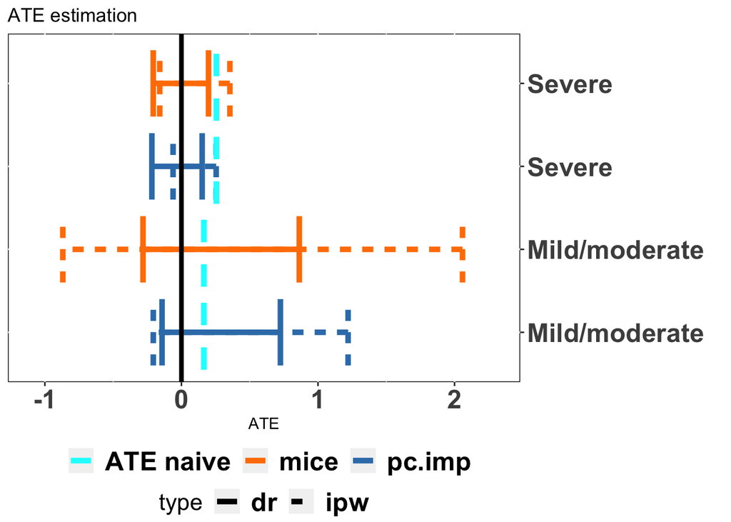

```
## [1] "GRF"
```

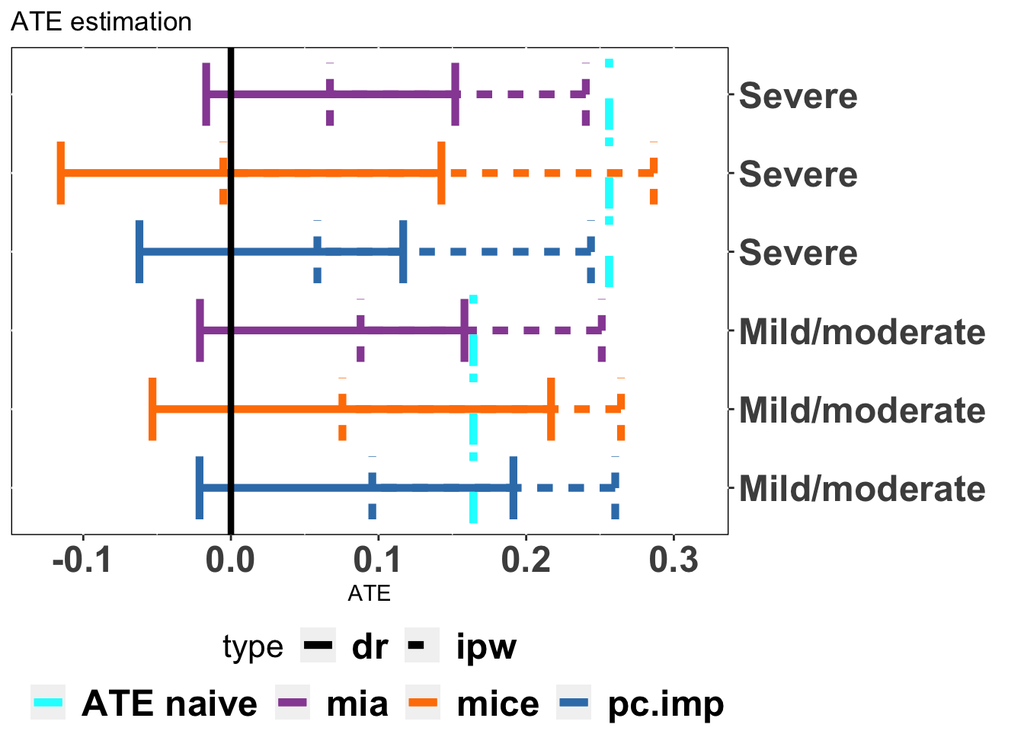

### 4.1.2 ATE for pupil reactivity

```
## [1] "GLM"
```

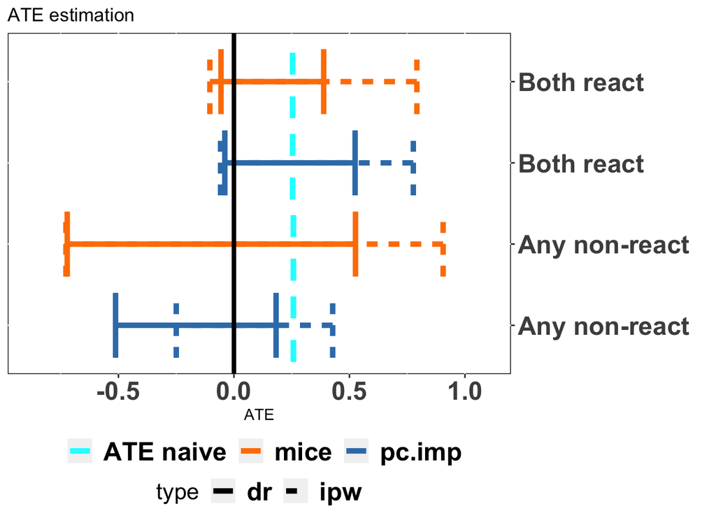

```
## [1] "GRF"
```

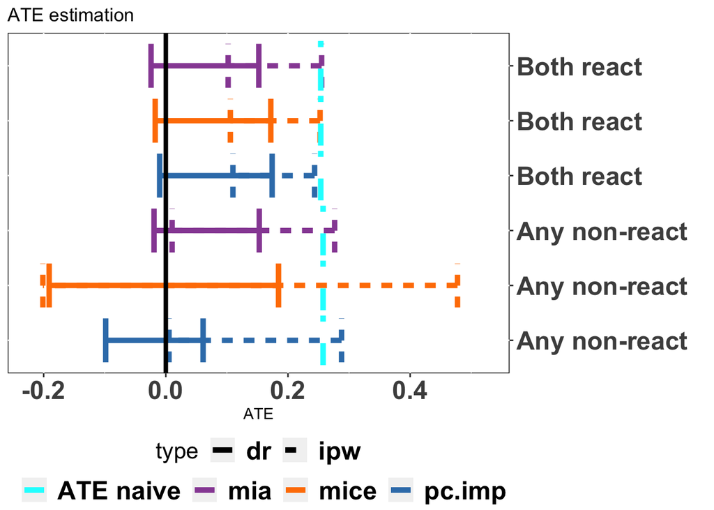